# Final Project

## State

State is a categorical value, our dataset need to be transformed to numerical data inorder to be used by the algorithms seen during the course, to code this column we will transform each factor to a int that represent each state.

```r
table(df$State)
```

```
##
##              Alabama               Alaska              Arizona
##                 4504                 5865                10184
##             Arkansas           California             Colorado
##                 5304                10943                 9363
##          Connecticut             Delaware District of Columbia
##                 9781                 3987                 3237
##              Florida              Georgia                 Guam
##                13392                 9235                 2266
##               Hawaii                Idaho             Illinois
##                 7746                 6279                 4055
##              Indiana                 Iowa               Kansas
##                10465                 8949                11245
##             Kentucky            Louisiana                Maine
##                 4021                 5623                10645
##             Maryland        Massachusetts             Michigan
##                16416                11027                10056
##            Minnesota          Mississippi             Missouri
##                16820                 4238                 7437
##              Montana             Nebraska               Nevada
##                 7047                 7473                 3188
##        New Hampshire           New Jersey           New Mexico
##                 6756                 8208                 4758
##             New York       North Carolina         North Dakota
##                17798                 4505                 4152
##                 Ohio             Oklahoma               Oregon
##                16481                 5775                 5755
##         Pennsylvania          Puerto Rico         Rhode Island
##                 4582                 5509                 5892
##       South Carolina         South Dakota            Tennessee
##                10036                 7423                 5263
##                Texas                 Utah              Vermont
##                14239                 9826                 8811
##       Virgin Islands             Virginia           Washington
##                 1528                10416                26150
##        West Virginia            Wisconsin              Wyoming
##                 4981                11274                 4141
```

```r
cdf$State <- factor(df$State)

# Asign a unique value to each factor
cdf$State <- as.integer(cdf$State)
```

## Gender

Gender, in this case, is a binary class male or female, so we will do a binary encoding where 0 represents female and 1 male.

```r
table(df$Gender, useNA = "ifany")
```

```
##
## Female   Male
## 235843 209207
```

```r
cdf$Gender <- ifelse(df$Gender == "Female", 0, 1)
table(cdf$Gender)
```

```
##
##      0      1
## 235843 209207
```

## General health

General health is the same type as state but we have nan’s, to deal with them we will initialy fill them with the mode, that in this case is 4.

```r
numeric_general_health <- factor(df$GeneralHealth, levels = c("Poor", "Fair", "Good", "Very good", "Excellent"))

#Fill NAN's with mode (4)
cdf$GeneralHealth <- ifelse(is.na(numeric_general_health), 4, as.integer(numeric_general_health))
table(cdf$GeneralHealth)
```

```
##
##      1      2      3      4      5
##  19736  60264 143583 149599  71868
```

## PhysicalHealthDays

PhysicalHealthDays is a numeric value that has nan’s, because it won’t make sense to have 3.2 days off or 0.4 we won’t calculate the mean and we will use the mode again.

```r
PhysicalHealthDays_frq <- table(df$PhysicalHealthDays, useNA = "ifany")
mode_PhysicalHealthDays <- names(PhysicalHealthDays_frq[which.max(PhysicalHealthDays_frq)])

cdf$PhysicalHealthDays <- ifelse(is.na(df$PhysicalHealthDays), as.numeric(mode_PhysicalHealthDays),as.numeric(df$PhysicalHealthDays))

table(cdf$PhysicalHealthDays)
```

```
##
##      0      1      2      3      4      5      6      7      8      9     10
## 278664  17250  25256  15948   8462  15315   2538   9348   1761    411  10589
##     11     12     13     14     15     16     17     18     19     20     21
##    161   1111    162   5029   8787    255    185    271     48   5421   1038
##     22     23     24     25     26     27     28     29     30
##    140     99    125   2181    109    188    751    365  33082
```

## MentalHealthDays

We will procede as same as with PhysicalHealthDays.

```r
MentalHealthDays_frq <- table(df$MentalHealthDays, useNA = "ifany")
mode_MentalHealthDays <- names(MentalHealthDays_frq[which.max(MentalHealthDays_frq)])

cdf$MentalHealthDays <- ifelse(is.na(df$MentalHealthDays), as.numeric(mode_MentalHealthDays),as.numeric(df$MentalHealthDays))

table(cdf$MentalHealthDays)
```

```
##
##      0      1      2      3      4      5      6      7      8      9     10
## 274214  14409  23785  15345   7943  19951   2305   7844   1749    322  15414
##     11     12     13     14     15     16     17     18     19     20     21
##    121   1259    169   2871  14519    280    244    319     47   9150    549
##     22     23     24     25     26     27     28     29     30
##    193     97    124   3078    106    241    910    502  26990
```

## LastCheckupTime

With this column we will convert each categorical factor to a integer representing that class, and a -1 when we find any NAN, in this case we don’t have any.

```r
table(df$LastCheckupTime, useNA = "ifany")
```

```
##
##
##                                                    8264
##                                     5 or more years ago
##                                                   19076
##  Within past 2 years (1 year but less than 2 years ago)
##                                                   41918
## Within past 5 years (2 years but less than 5 years ago)
##                                                   24881
##      Within past year (anytime less than 12 months ago)
##                                                  350911
```

```r
numeric_checkup_time <- factor(df$LastCheckupTime)

cdf$LastCheckupTime <- ifelse(is.na(numeric_checkup_time), -1, as.integer(numeric_checkup_time))
table(cdf$LastCheckupTime)
```

```
##
##      1      2      3      4      5
##   8264  19076  41918  24881 350911
```

## PhysicalActivities

PhysicalActivities is a binary class with some columns being blank saces, representing a yes, and orinary yes and no.

```r
table(df$PhysicalActivities, useNA = "ifany")
```

```
##
##            No    Yes
##   1056 106462 337532
```

```r
cdf$PhysicalActivities <- ifelse(df$PhysicalActivities == "", 1, ifelse(df$PhysicalActivities == "Yes", 1,0))
table(cdf$PhysicalActivities)
```

```
##
##      0      1
## 106462 338588
```

## SleepHours

```r
SleepHours_frq <- table(df$SleepHours, useNA = "ifany")
mode_SleepHours <- names(SleepHours_frq[which.max(SleepHours_frq)])

cdf$SleepHours <- ifelse(is.na(df$SleepHours), as.numeric(mode_SleepHours),as.numeric(df$SleepHours))
table(cdf$SleepHours)
```

```
##
##      1      2      3      4      5      6      7      8      9     10     11
##   1154   1549   3260  12433  30122  95880 138298 125442  21210  10459    686
##     12     13     14     15     16     17     18     19     20     21     22
##   3004    165    295    317    329     27    168     16    143      4     19
##     23     24
##     18     52
```

## RemovedTeeth

RemovedTeeth is as same as LastCheckupTime

```r
table(df$RemovedTeeth, useNA = "ifany")
```

```
##
##                                        1 to 5 6 or more, but not all
##                  11309                 129287                  45565
##                    All           None of them
##                  25449                 233440
```

```r
cdf$RemovedTeeth <- ifelse(df$RemovedTeeth == "", 1, ifelse(grepl("None", df$RemovedTeeth),0,1))
table(cdf$RemovedTeeth)
```

```
##
##      0      1
## 233440 211610
```

## HadHeartAttack

Hearth atack is as same as PhysicalActivities

```r
table(df$HadHeartAttack, useNA = "ifany")
```

```
##
##            No    Yes
##   3021 416925  25104
```

```r
cdf$HadHeartAttack <- ifelse(df$HadHeartAttack == "", 0, ifelse(df$HadHeartAttack == "No", 0,1))
table(cdf$HadHeartAttack)
```

```
##
##      0      1
## 419946  25104
```

## HadAngina

HadAngina is as same as PhysicalActivities

```r
table(df$HadAngina, useNA = "ifany")
```

```
##
##            No    Yes
##   4361 414141  26548
```

```r
cdf$HadAngina <- ifelse(df$HadAngina == "", 0, ifelse(df$HadAngina == "No", 0,1))
table(cdf$HadAngina)
```

```
##
##      0      1
## 418502  26548
```

## HadStroke

Same as PhysicalActivities

```r
table(df$HadStroke, useNA = "ifany")
```

```
##
##            No    Yes
##   1514 424301  19235
```

```r
cdf$HadStroke <- ifelse(df$HadStroke == "", 0, ifelse(df$HadStroke == "No", 0,1))
table(cdf$HadStroke)
```

```
##
##      0      1
## 425815  19235
```

## HadAsthma

Same as PhysicalActivities

```r
table(df$HadAsthma, useNA = "ifany")
```

```
##
##            No    Yes
##   1729 376634  66687
```

```r
cdf$HadAsthma <- ifelse(df$HadAsthma == "", 0, ifelse(df$HadAsthma == "No", 0,1))
table(cdf$HadAsthma)
```

```
##
##      0      1
## 378363  66687
```

## HadSkinCancer

Same as PhysicalActivities

```r
table(df$HadSkinCancer, useNA = "ifany")
```

```
##
##            No    Yes
##   3101 406467  35482
```

```r
cdf$HadSkinCancer <- ifelse(df$HadSkinCancer == "", 0, ifelse(df$HadSkinCancer == "No", 0,1))
table(cdf$HadSkinCancer)
```

```
##
##      0      1
## 409568  35482
```

## HadCOPD

Same as PhysicalActivities

```r
table(df$HadCOPD, useNA = "ifany")
```

```
##
##            No    Yes
##   2174 407222  35654
```

```r
cdf$HadCOPD <- ifelse(df$HadCOPD == "", 0, ifelse(df$HadCOPD == "No", 0,1))
table(cdf$HadCOPD)
```

```
##
##      0      1
## 409396  35654
```

## HadDepressiveDisorder

Same as PhysicalActivities

```r
table(df$HadDepressiveDisorder, useNA = "ifany")
```

```
##
##            No    Yes
##   2761 350882  91407
```

```r
cdf$HadDepressiveDisorder <- ifelse(df$HadDepressiveDisorder == "", 0, ifelse(df$HadDepressiveDisorder == "No", 0,1))
table(cdf$HadDepressiveDisorder)
```

```
##
##      0      1
## 353643  91407
```

## HadKidneyDisease

Same as PhysicalActivities

```r
table(df$HadKidneyDisease, useNA = "ifany")
```

```
##
##            No    Yes
##   1882 422858  20310
```

```r
cdf$HadKidneyDisease <- ifelse(df$HadKidneyDisease == "", 0, ifelse(df$HadKidneyDisease == "No", 0,1))
table(cdf$HadKidneyDisease)
```

```
##
##      0      1
## 424740  20310
```

## HadArthritis

Same as PhysicalActivities

```r
table(df$HadArthritis, useNA = "ifany")
```

```
##
##            No    Yes
##   2587 291328 151135
```

```r
cdf$HadArthritis <- ifelse(df$HadArthritis == "", 0, ifelse(df$HadArthritis == "No", 0,1))
table(cdf$HadArthritis)
```

```
##
##      0      1
## 293915 151135
```

## HadDiabetes

```r
table(df$HadDiabetes, useNA = "ifany")
```

```
##
##                                                                              No
##                                    1045                                  368694
## No, pre-diabetes or borderline diabetes                                     Yes
##                                   10325                                   61150
## Yes, but only during pregnancy (female)
##                                    3836
```

```r
cdf$HadDiabetes <- ifelse(df$HadDiabetes == "", 0, ifelse(grepl("No",df$HadDiabetes), 0,1))
table(cdf$HadDiabetes)
```

```
##
##      0      1
## 380064  64986
```

## DeafOrHardOfHearing

Same as PhysicalActivities

```r
table(df$DeafOrHardOfHearing, useNA = "ifany")
```

```
##
##            No    Yes
##  20589 385519  38942
```

```r
cdf$DeafOrHardOfHearing <- ifelse(df$DeafOrHardOfHearing == "", 0, ifelse(df$DeafOrHardOfHearing == "No", 0,1))
table(cdf$DeafOrHardOfHearing)
```

```
##
##      0      1
## 406108  38942
```

## BlindOrVisionDifficulty

Same as PhysicalActivities

```r
table(df$BlindOrVisionDifficulty, useNA = "ifany")
```

```
##
##            No    Yes
##  21504 399893  23653
```

```r
cdf$BlindOrVisionDifficulty <- ifelse(df$BlindOrVisionDifficulty == "", 0, ifelse(df$BlindOrVisionDifficulty == "No", 0,1))
table(cdf$BlindOrVisionDifficulty)
```

```
##
##      0      1
## 421397  23653
```

## DifficultyConcentrating

Same as PhysicalActivities

```r
table(df$DifficultyConcentrating, useNA = "ifany")
```

```
##
##            No    Yes
##  24177 370775  50098
```

```r
cdf$DifficultyConcentrating <- ifelse(df$DifficultyConcentrating == "", 0, ifelse(df$DifficultyConcentrating == "No", 0,1))
table(cdf$DifficultyConcentrating)
```

```
##
##      0      1
## 394952  50098
```

## DifficultyWalking

Same as PhysicalActivities

```r
table(df$DifficultyWalking, useNA = "ifany")
```

```
##
##            No    Yes
##  23951 353022  68077
```

```r
cdf$DifficultyWalking <- ifelse(df$DifficultyWalking == "", 0, ifelse(df$DifficultyWalking == "No", 0,1))
table(cdf$DifficultyWalking)
```

```
##
##      0      1
## 376973  68077
```

## DifficultyDressingBathing

Same as PhysicalActivities

```r
table(df$DifficultyDressingBathing, useNA = "ifany")
```

```
##
##            No    Yes
##  23856 404382  16812
```

```r
cdf$DifficultyDressingBathing <- ifelse(df$DifficultyDressingBathing == "", 0, ifelse(df$DifficultyDressingBathing == "No", 0,1))
table(cdf$DifficultyDressingBathing)
```

```
##
##      0      1
## 428238  16812
```

## DifficultyErrands

Same as PhysicalActivities

```r
table(df$DifficultyErrands, useNA = "ifany")
```

```
##
##            No    Yes
##  25595 387009  32446
```

```r
cdf$DifficultyErrands <- ifelse(df$DifficultyErrands == "", 0, ifelse(df$DifficultyErrands == "No", 0,1))
table(cdf$DifficultyErrands)
```

```
##
##      0      1
## 412604  32446
```

## SmokerStatus

This case is similar to HadDiabetes, where we only care if they smoke or not, we will binarice this column.

```r
table(df$SmokerStatus, useNA = "ifany")
```

```
##
##                                       Current smoker - now smokes every day
##                                 35401                                 36003
## Current smoker - now smokes some days                         Former smoker
##                                 13936                                113770
##                          Never smoked
##                                245940
```

```r
cdf$SmokerStatus <- ifelse(df$SmokerStatus == "", 0, ifelse(grepl("Never smoked",df$SmokerStatus), 0,1))
table(cdf$SmokerStatus)
```

```
##
##      0      1
## 281341 163709
```

## ECigarretteUsage

```r
table(df$ECigaretteUsage, useNA = "ifany")
```

```
##
##
##                                     35599
## Never used e-cigarettes in my entire life
##                                    311973
##                    Not at all (right now)
##                                     75363
##                        Use them every day
##                                     10382
##                        Use them some days
##                                     11733
```

```r
cdf$ECigaretteUsage <- ifelse(df$ECigaretteUsage == "", 0, ifelse(grepl("Never smoked",df$ECigaretteUsage) | grepl("Not at all",df$ECigaretteUsage) , 0,1))
table(cdf$ECigaretteUsage)
```

```
##
##      0      1
## 110962 334088
```

## ChestScan

Same as PhysicalActivities

```r
table(df$ChestScan, useNA = "ifany")
```

```
##
##            No    Yes
##  55979 223212 165859
```

```r
cdf$ChestScan <- ifelse(df$ChestScan == "", 0, ifelse(df$ChestScan == "No", 0,1))
table(cdf$ChestScan)
```

```
##
##      0      1
## 279191 165859
```

## RaceEthnicityCategory

Same as LastCheckupTime

```r
cdf$RaceEthnicityCategory <- df$RaceEthnicityCategory
table(df$RaceEthnicityCategory, useNA = "ifany")
```

```
##
##                                    Black only, Non-Hispanic
##                         14006                         35439
##                      Hispanic     Multiracial, Non-Hispanic
##                         42911                          9577
## Other race only, Non-Hispanic      White only, Non-Hispanic
##                         22712                        320405
```

```r
cdf$RaceEthnicityCategory[df$RaceEthnicityCategory == ""] <- "White only, Non-Hispanic"
cdf$RaceEthnicityCategory <- factor(cdf$RaceEthnicityCategory)
  cdf$RaceEthnicityCategory <- as.integer(cdf$RaceEthnicityCategory)
  table(cdf$RaceEthnicityCategory)
```

```
##
##      1      2      3      4      5
##  35439  42911   9577  22712 334411
```

## AgeCategory

Same as LastCheckupTime

```r
table(df$AgeCategory, useNA = "ifany")
```

```
##
##                    Age 18 to 24    Age 25 to 29    Age 30 to 34    Age 35 to 39
##            9035           26939           21989           25804           28524
##    Age 40 to 44    Age 45 to 49    Age 50 to 54    Age 55 to 59    Age 60 to 64
##           29941           28530           33643           36817           44508
##    Age 65 to 69    Age 70 to 74    Age 75 to 79 Age 80 or older
##           47095           43469           32515           36241
```

```r
cdf$AgeCategory[df$AgeCategory == ""] <- "Age 65 to 69"
cdf$AgeCategory <- factor(cdf$AgeCategory)
  cdf$AgeCategory <- as.integer(cdf$AgeCategory)
  table(cdf$AgeCategory)
```

```
##
##     1     2     3     4     5     6     7     8     9    10    11    12    13
## 26939 21989 25804 28524 29941 28530 33643 36817 44508 56130 43469 32515 36241
```

## HeightInMeters

Same as PhysicalHealthDays

```r
height_frq <- table(df$HeightInMeters, useNA = "ifany")

mode_height <- names(height_frq[which.max(height_frq)])
cdf$HeightInMeters <- ifelse(is.na(df$HeightInMeters),as.numeric(mode_height),as.numeric(df$HeightInMeters) )

table(cdf$HeightInMeters, useNA = "ifany")
```

```
##
##  0.91  0.92  0.95  0.97  0.99     1  1.02  1.03  1.04  1.05  1.06  1.07  1.08
##    24     1     1     4     1     4     3     3    18    29     5     8     2
##  1.09   1.1  1.12  1.14  1.15  1.16  1.17  1.18  1.19   1.2  1.22  1.24  1.25
##     2     4     3     2     3     1     4     3     8    10    79    23     7
##  1.27   1.3  1.32  1.33  1.35  1.37  1.38   1.4  1.42  1.43  1.44  1.45  1.46
##    22    36    21     1   122    69     1   135   368     5     2   812     8
##  1.47  1.48  1.49   1.5  1.51  1.52  1.53  1.54  1.55  1.56  1.57  1.58  1.59
##  1428    18    24  4444    33 13541    64    58 13946    73 26944    85    48
##   1.6  1.61  1.62  1.63  1.64  1.65  1.66  1.67  1.68  1.69   1.7  1.71  1.72
## 28296    32   112 35622    88 32785    50   103 65352    62 34038    38   114
##  1.73  1.74  1.75  1.76  1.77  1.78  1.79   1.8  1.81  1.82  1.83  1.84  1.85
## 30910    68 29157    44    45 32038    36 24962    19    27 28294    17 14042
##  1.86  1.87  1.88  1.89   1.9  1.91  1.92  1.93  1.94  1.95  1.96  1.98     2
##    19    14 11789     6    24  6429     2  4217     1     4  1831   904     2
##  2.01  2.02  2.03  2.05  2.06  2.07  2.08  2.11  2.13  2.16  2.18  2.21  2.24
##   421     1   255     1    74     1    34    24    29    10    10     9     2
##  2.26  2.29  2.34  2.36  2.41
##    11     5     4     1     5
```

## WeightInKilograms

Same as PhysicalHealthDays

```r
weight_frq <- table(df$WeightInKilograms)

mode_weight <- names(weight_frq[which.max(weight_frq)])
cdf$WeightInKilograms <- ifelse(is.na(df$WeightInKilograms),as.numeric(mode_weight),as.numeric(df$WeightInKilograms) )

table(cdf$WeightInKilograms, useNA = "ifany")
```

```
##
##  22.68     23  23.13  23.59     24  24.04  24.49  24.95   25.4  25.85     26
##     10      1      1      2      1      3      2      6      3      3      1
##  26.31  26.76  27.22     28  28.12  28.58  29.03  29.48     30  30.39  30.84
##      2      1     15      1      4      3      3     10      2      4      8
##   31.3  31.75     32  32.21  32.66  33.11  33.57  34.02  34.47  34.93  35.38
##      2     31      2      2      6      5      9     31      8      9     18
##  35.83  36.29  36.74     37  37.19  37.65     38   38.1  38.56  39.01  39.46
##      7     92     11      2     27     21      2     28    108     25     33
##  39.92     40  40.37  40.82     41  41.28  41.73     42  42.18  42.64  43.09
##     61      2     52    291      3     31     95      1     72     88    337
##  43.54     44  44.45  44.91     45  45.36  45.81     46  46.27  46.72     47
##    104    133    276    148     14   1396    117      6    306    305      7
##  47.17  47.63     48  48.08  48.53  48.99     49  49.44   49.9     50  50.35
##    258   1275     21    326    358    547      7    255   2775     50    207
##   50.8     51  51.26  51.71     52  52.16  52.62     53  53.07  53.52  53.98
##    904      6    446    528     26   3046    560     20    635   1141    380
##     54  54.43  54.88     55  55.34  55.79     56  56.25   56.7     57  57.15
##     26   6501    372     49    906    794     22    756   5767     22    758
##  57.61     58  58.06  58.51  58.97     59  59.42  59.87     60  60.33  60.78
##   1035     43   1493    588   9812     18    363   1302    103    805    963
##     61  61.23  61.69     62  62.14   62.6     63  63.05   63.5  63.96     64
##     17   8192    966     60   1017   1820     41    593  12924    467     33
##  64.41  64.86     65  65.32  65.77     66  66.22  66.68     67  67.13  67.59
##   1580   1061    120    846   8645     21    850   1180     38   1826    641
##     68  68.04  68.49  68.95     69   69.4  69.85     70  70.31  70.76     71
##     57  17595    501   1472     24   1046   1119    170   8170   1132     22
##  71.21  71.67     72  72.12  72.57     73  73.03  73.48  73.94     74  74.39
##   1139   1806     80    646  17177     24    541   1761   1252     40   1037
##  74.84     75   75.3  75.75     76   76.2  76.66     77  77.11  77.56     78
##  10809    125    647   1147     38   2153    751     20  15979    559     46
##  78.02  78.47  78.93     79  79.38  79.83     80  80.29  80.74     81  81.19
##   1861   1016   1146     16  11722    989    148    737   2004     12    813
##  81.65     82   82.1  82.55     83  83.01  83.46  83.91     84  84.37  84.82
##  19709     27    547   1465     23   1065   1062  10193     31    944   1096
##     85  85.28  85.73     86  86.18  86.64     87  87.09  87.54     88  88.45
##     58   1094   1002     21  14202    426     17   1243    761    799   6789
##   88.9     89  89.36  89.81     90  90.26  90.72     91  91.17  91.63     92
##    829      9    866   1626     63    547  63307      7    411    735     24
##  92.08  92.53  92.99     93  93.44  93.89     94  94.35   94.8     95  95.25
```

[output cut: 56 more lines]

```
##      3     13      1      1      2      4      2      2      1      6      1
##    215 215.46 216.82    217 217.27 217.72 219.09 219.99    220 221.35    222
##      1      8      1      1      1      8      1      8      3      1      1
## 222.26 223.17 223.62 224.53 224.98  226.8 227.25  227.7 228.16 228.61 229.06
##      5      1      1      1      1     33      2      2      1      1      2
## 229.52 229.97    230 230.42 230.88 231.33 231.79 232.69  233.6 234.51 234.96
##      2      2      1      1      4      3      2      1      1      2      1
## 235.87    236 238.14 238.59 239.04    240  240.4 242.67 244.94  246.3 247.21
##      2      1      2      1      1      2      6      1      2      1      1
## 248.57 249.48    250 250.38  252.2 254.01    255 256.28 258.55 263.08    265
##      1     10      1      1      1      2      1      2      1      2      1
## 265.35    272 272.16 273.06 273.52 274.42 276.24 278.96    280 280.32    281
##      1      1      6      1      2      1      1      1      1      1      1
## 281.68 284.86    285  290.3 292.57
##      1      1      1      2      1
```

## BMI

As we know BMI is a linear combinarion of Height and Weigth, first of all we will take a look at the distribution of the data to check if we observe some strange data such as outliers.

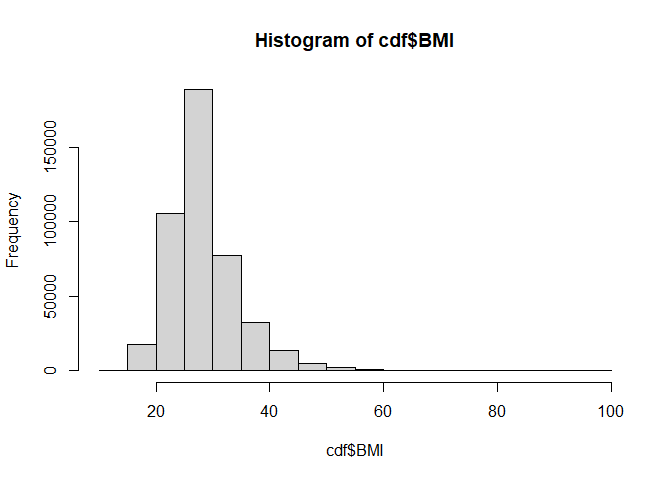

```r
BMI_frq <- table(df$BMI)
mode_BMI <- names(BMI_frq[which.max(BMI_frq)])
cdf$BMI <- ifelse(is.na(df$BMI),as.numeric(mode_BMI),as.numeric(df$BMI) )
hist(cdf$BMI)
```

As we can see this doesn’t follow a normal distributon and presents outliers, we will calculate the IQR to check which indidividuals exceed the 1.5 IQR.

```r
quantiles = quantile(cdf$BMI)
q1 <- quantiles[2]
q3 <- quantiles[4]

iqr = q3 - q1
lower_bound = q1 - 1.5 * iqr
upper_bound = q3 + 1.5 * iqr

outliers <- cdf$BMI[cdf$BMI < lower_bound | cdf$BMI > upper_bound]
cdf[cdf$BMI < lower_bound | cdf$BMI > upper_bound, ]
```

[output not shown]

[output cut: 27486 more lines]

```r
df <- cdf[!(cdf$BMI < lower_bound | cdf$BMI > upper_bound), ]
cdf <- cdf[!(cdf$BMI < lower_bound | cdf$BMI > upper_bound), ]
```

Now that we have deleted the outliers, arround 20k of them, we will take a look again at the distribution.

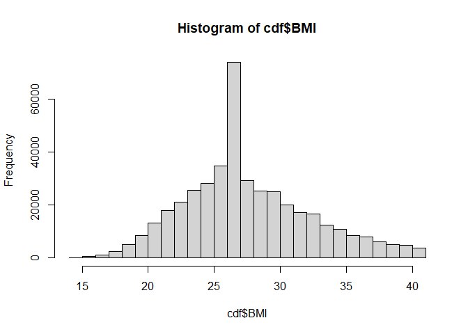

```r
hist(cdf$BMI)
```

## AlcoholDrinkers

Same as PhysicalActivities

```r
table(cdf$AlcoholDrinkers, useNA = "ifany")
```

```
##
##            No    Yes
##  45530 177121 203392
```

```r
cdf$AlcoholDrinkers <- ifelse(cdf$AlcoholDrinkers == "", 1, ifelse(cdf$AlcoholDrinkers == "No", 0,1))
table(cdf$AlcoholDrinkers)
```

```
##
##      0      1
## 177121 248922
```

## HIVTesting

Same as PhysicalActivities

```r
table(cdf$HIVTesting, useNA = "ifany")
```

```
##
##            No    Yes
##  64261 239670 122112
```

```r
cdf$HIVTesting <- ifelse(cdf$HIVTesting == "", 0, ifelse(cdf$HIVTesting == "No", 0,1))
table(cdf$HIVTesting)
```

```
##
##      0      1
## 303931 122112
```

## FluVaxLast12

Same as PhysicalActivities

```r
table(cdf$FluVaxLast12, useNA = "ifany")
```

```
##
##            No    Yes
##  46039 179845 200159
```

```r
cdf$FluVaxLast12 <- ifelse(cdf$FluVaxLast12 == "", 1, ifelse(cdf$FluVaxLast12 == "No", 0,1))
table(cdf$FluVaxLast12)
```

```
##
##      0      1
## 179845 246198
```

## PneumoVaxEver

Same as PhysicalActivities

```r
table(cdf$PneumoVaxEver, useNA = "ifany")
```

```
##
##            No    Yes
##  74698 205928 145417
```

```r
cdf$PneumoVaxEver <- ifelse(cdf$PneumoVaxEver == "", 0, ifelse(cdf$PneumoVaxEver == "No", 0,1))
table(cdf$PneumoVaxEver)
```

```
##
##      0      1
## 280626 145417
```

## TetanusLast10Tdap

Same as HadDiabetes or SmokerStatus, we binarize this column.

```r
tetanus_frq <- table(cdf$TetanusLast10Tdap, useNA = "ifany")
tetanus_frq
```

```
##
##
##                                                     79902
## No, did not receive any tetanus shot in the past 10 years
##                                                    115829
##                                        Yes, received Tdap
##                                                     95339
##         Yes, received tetanus shot but not sure what type
##                                                    108747
##                  Yes, received tetanus shot, but not Tdap
##                                                     26226
```

```r
mode_TetanusLast10Tdap <- names(tetanus_frq[which.max(tetanus_frq)])
mode_TetanusLast10Tdap
```

```
## [1] "No, did not receive any tetanus shot in the past 10 years"
```

```r
cdf$TetanusLast10Tdap <- ifelse(cdf$TetanusLast10Tdap == "",0,ifelse(grepl(cdf$TetanusLast10Tdap, "No"), 0, 1) )
table(cdf$TetanusLast10Tdap, useNA = "ifany")
```

```
##
##      0      1
##  79902 346141
```

## HighRiskLastYear

Same as PhysicalActivities

```r
table(cdf$HighRiskLastYear, useNA = "ifany")
```

```
##
##            No    Yes
##  49398 360367  16278
```

```r
cdf$HighRiskLastYear <- ifelse(cdf$HighRiskLastYear == "", 0, ifelse(cdf$HighRiskLastYear == "No", 0,1))
table(cdf$HighRiskLastYear)
```

```
##
##      0      1
## 409765  16278
```

## CovidPos

Same as PhysicalActivities

```r
cdf$CovidPos <- df$CovidPos
table(df$CovidPos, useNA = "ifany")
```

```
##
##
##                                                         49532
##                                                            No
##                                                        259037
## Tested positive using home test without a health professional
##                                                         12938
##                                                           Yes
##                                                        104536
```

```r
cdf$CovidPos <- ifelse(df$CovidPos == "",0,ifelse(grepl("No", df$CovidPos), 0, 1))
table(cdf$CovidPos, useNA = "ifany")
```

```
##
##      0      1
## 308569 117474
```

Finally we have all of our data cleaned and addressed problems such as NAN’s or outliers, to check we will run a str command to be sure.

```r
str(cdf)
```

```
## 'data.frame':    426043 obs. of  40 variables:
##  $ State                    : int  1 1 1 1 1 1 1 1 1 1 ...
##  $ Gender                   : num  0 0 0 0 0 1 0 0 0 0 ...
##  $ GeneralHealth            : num  4 5 4 5 2 1 4 3 3 3 ...
##  $ PhysicalHealthDays       : num  0 0 2 0 2 1 0 0 0 1 ...
##  $ MentalHealthDays         : num  0 0 3 0 0 0 0 0 0 0 ...
##  $ LastCheckupTime          : int  5 1 5 5 5 5 5 5 5 5 ...
##  $ PhysicalActivities       : num  0 0 1 1 1 0 1 0 1 1 ...
##  $ SleepHours               : num  8 6 5 7 9 7 7 8 6 7 ...
##  $ RemovedTeeth             : num  1 1 1 1 1 1 1 1 1 1 ...
##  $ HadHeartAttack           : num  0 0 0 0 0 1 0 0 0 0 ...
##  $ HadAngina                : num  0 0 0 0 0 0 0 0 0 0 ...
##  $ HadStroke                : num  0 0 0 0 0 1 0 0 0 0 ...
##  $ HadAsthma                : num  0 0 0 1 0 0 0 0 0 0 ...
##  $ HadSkinCancer            : num  0 1 1 0 0 0 0 0 1 0 ...
```

[output cut: 26 more lines]

Finally we will look at the correlation matrix to take a look at the data, see if there’s some correlated columns that surprises us and helps with the formulation of the questions.

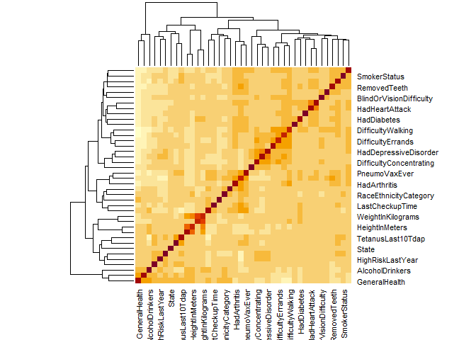

```r
heatmap(cor(cdf))
```

```r
write.csv(df, "FPdata_CLEAN.csv", row.names = FALSE)
```